# Ambient Noise Seismology: From Theory to Practice

## A Comprehensive Course in Seismic Interferometry and Ambient Noise Processing

**Course Structure:**

| Module | Topic | Type |
| --- | --- | --- |
| 1 | Introduction to Seismic Ambient Noise | Theory |
| 2 | Seismic Data Handling with ObsPy | Practice |
| 3 | The Cross-Correlation Theorem | Theory + Practice |
| 4 | Green's Function Retrieval from Ambient Noise | Theory |
| 5 | Ambient Noise Preprocessing | Theory + Practice |
| 6 | Cross-Correlation Computation | Practice |
| 7 | Stacking Methods | Theory + Practice |
| 8 | Optimal Processing of Noise Correlations | Theory + Practice |
| 9 | Surface Wave Dispersion Analysis | Theory + Practice |
| 10 | Ambient Noise Tomography: Inversion | Theory + Practice |
| 11 | Seismic Interferometry Principles | Theory |
| 12 | Seismic Velocity Changes (dv/v) Monitoring | Theory + Practice |
| 13 | HVSR / MHVSR Method | Theory + Practice |
| 14 | NoisePy: Large-Scale Ambient Noise Processing | Practice |
| 15 | Applications and Case Studies | Theory + Practice |
| 16 | Dense Arrays and Advanced Applications | Theory + Practice |

**Key References:**

- Aki, K. (1957). Space and time spectra of stationary stochastic waves, with special reference to microtremors. *Bull. Earthquake Res. Inst.*, 35, 415-457.
- Bensen, G.D., Ritzwoller, M.H., Barmin, M.P., et al. (2007). Processing seismic ambient noise data to obtain reliable broad-band surface wave dispersion measurements. *Geophys. J. Int.*, 169, 1239-1260.
- Bensen, G.D., Ritzwoller, M.H. & Shapiro, N.M. (2008). Broadband ambient noise surface wave tomography across the United States. *J. Geophys. Res.*, 113, B05306.
- Campillo, M. & Paul, A. (2003). Long-range correlations in the diffuse seismic coda. *Science*, 299, 547-549.
- Campillo, M. & Roux, P. (2015). Crust and Lithospheric Structure - Seismic Imaging and Monitoring with Ambient Noise Correlations. *Treatise on Geophysics*, 2nd ed., Vol. 1, pp. 391-417.
- Cabrera-Pérez, I. et al. (2023). Geothermal and structural features of La Palma island imaged by ambient noise tomography. *Sci. Rep.*, 13, 12892.
- Chmiel, M. et al. (2019). Ambient noise multimode Rayleigh and Love wave tomography to determine the shear velocity structure above the Groningen gas field. *Geophys. J. Int.*, 218, 1781-1795.
- Claerbout, J.F. (1968). Synthesis of a layered medium from its acoustic transmission response. *Geophysics*, 33, 264-269.
- Cox, B.R. et al. (2020). A statistical representation and frequency-domain window-rejection algorithm for single-station HVSR measurements. *Geophys. J. Int.*, 221(3), 2170-2183.
- Fichtner, A., Bowden, D. & Ermert, L. (2020). Optimal processing for seismic noise correlations. *Geophys. J. Int.*, 223, 1548-1564.
- Fichtner, A. et al. (2017). Generalised interferometry I: Theory for inter-station correlations. *Geophys. J. Int.*, 208, 603-638.
- Lecocq, T. et al. (2014). MSNoise, a Python Package for Monitoring Seismic Velocity Changes Using Ambient Seismic Noise. *Seismol. Res. Lett.*, 85(3), 715‑726.
- Jiang, C. & Denolle, M.A. (2020). NoisePy: A New High-Performance Python Tool for Ambient-Noise Seismology. *Seismol. Res. Lett.*, 91(3), 1853-1866.
- Brenguier, F., Rivet, D., Obermann, A., et al. (2016). 4-D noise-based seismology at volcanoes. *J. Volcanol. Geotherm. Res.*, 321, 182-195.
- Lobkis, O.I. & Weaver, R.L. (2001). On the emergence of the Green's function in the correlations of a diffuse field. *J. Acoust. Soc. Am.*, 110(6), 3011-3017.
- Molnar, S. et al. (2022). A review of the microtremor horizontal-to-vertical spectral ratio (MHVSR) method. *J. Seismol.*, 26, 653-685.
- Rawlinson, N. et al. (2010). Seismic tomography: A window into deep Earth. *Phys. Earth Planet. Inter.*, 178, 101-135.
- Ryberg, T. et al. (2022). Ambient seismic noise analysis of LARGE-N data for mineral exploration in the Central Erzgebirge, Germany. *Solid Earth*, 13, 519-533.
- Schimmel, M. & Paulssen, H. (1997). Noise reduction and detection of weak, coherent signals through phase-weighted stacks. *Geophys. J. Int.*, 130, 497-505.
- Sens-Schoenfelder, C. & Wegler, U. (2006). Passive image interferometry and seasonal variations of seismic velocities at Merapi Volcano, Indonesia. *Geophys. Res. Lett.*, 33, L21302.
- Shapiro, N.M. & Campillo, M. (2004). Emergence of broadband Rayleigh waves from correlations of the ambient seismic noise. *Geophys. Res. Lett.*, 31, L07614.
- Snieder, R. (2004). Extracting the Green's function from the correlation of coda waves. *Phys. Rev. E*, 69, 046610.
- Stehly, L. et al. (2024). Dynamic of seismic noise sources in the Mediterranean Sea: implication for monitoring using noise correlations. *C. R. Géoscience*, doi:10.5802/crgeos.241.
- Wapenaar, K. (2004). Retrieving the elastodynamic Green's function of an arbitrary inhomogeneous medium by cross correlation. *Phys. Rev. Lett.*, 93, 254301.

**Textbooks:**

- Nakata, N., Gualtieri, L. & Fichtner, A. (2019). *Seismic Ambient Noise*. Cambridge University Press.
- Shearer, P.M. (2019). *Introduction to Seismology*, 3rd ed. Cambridge University Press.

**Software Libraries:**

- [ObsPy](https://docs.obspy.org/) - Python framework for seismology (Beyreuther et al., 2010; Megies et al., 2011)
- NoisePy - High-performance ambient noise processing (Jiang & Denolle, 2020)
- hvsrpy - HVSR processing (Vantassel, 2020; Cox et al., 2020)

```
All imports successful.
Ready to begin!
```

# Module 1: Introduction to Seismic Ambient Noise

## 1.1 What is Ambient Seismic Noise?

Seismic ambient noise is the **continuous background vibration** of the Earth's surface, present everywhere and at all times. Unlike earthquake signals, which are transient and localized, ambient noise is a **persistent, stochastic wavefield** generated by a variety of natural and anthropogenic sources.

> *"The Earth is not static but permanently vibrating even when no strong energetic sources of vibration are acting."* — Campillo & Roux (2015)

### Source Classification by Frequency Band

| Frequency Band | Period | Source Mechanism | Reference |
| --- | --- | --- | --- |
| **Infragravity waves (Earth's hum)** | > 30 s | Ocean infragravity waves, atmospheric pressure | Rhie & Romanowicz (2004) |
| **Primary microseisms** | ~10–20 s (peak ~14 s) | Direct ocean wave–seafloor interaction in shallow water | Hasselmann (1963) |
| **Secondary microseisms** | ~3–10 s (peak ~7 s) | Nonlinear wave–wave interaction (opposing wave trains) | Longuet-Higgins (1950) |
| **Short-period noise** | < 1 s | Cultural/anthropogenic: traffic, industry, wind | McNamara & Buland (2004) |

### The Microseismic Peaks

The ambient noise spectrum displays two characteristic peaks observable globally:

- **Primary microseism** (~0.07 Hz, period ~14 s): Generated by ocean swell interacting with the sloping sea floor in coastal areas. Energy is at the **same frequency** as the ocean waves. Amplitude varies with ocean wave activity and distance from coastlines.
- **Secondary microseism** (~0.14 Hz, period ~7 s): The dominant feature. Generated by the nonlinear interaction of two ocean wave trains traveling in **opposite directions** (Longuet-Higgins, 1950). This doubles the frequency (hence the name "double-frequency microseism"). The strongest and most spatially distributed ambient noise source.

### Noise Source Dynamics and Stationarity

A critical assumption for ambient noise cross-correlation is that noise sources are **diffuse** (isotropic in space) and **stationary** (constant over time). In practice, this is only approximately true.

**Stehly et al. (2024)** analyzed the dynamics of seismic noise sources in the Mediterranean Sea and showed that:

- At 7 s period, **North Atlantic sources dominate in winter** across all of Europe — the noise field is stable year-round (stationarity coefficient SC ≈ 0.96–1.0)
- In summer, **Adriatic Sea and Aegean Sea** contribute increasingly, causing discrete microseismic events lasting hours
- Near Mediterranean coastlines, SC drops below 0.94 regularly, indicating **non-stationary noise sources**
- Non-stationary noise introduces **systematic errors** into coda wave interferometry that must be corrected

> **Implication for ANT:** Combining both winter and summer data improves measurement quality by averaging over different source distributions (Stehly et al., 2024). For dv/v monitoring, one must separate true velocity changes from apparent changes caused by noise source variations.

### The New Low/High Noise Models

The **Peterson New Low Noise Model (NLNM)** and **New High Noise Model (NHNM)** (Peterson, 1993) define the expected range of ambient noise power spectral densities globally. Any seismic station can be characterized by comparing its noise spectrum to these reference curves using ObsPy's `PPSD` class.

```
1 Trace(s) in Stream:
IU.ANMO.00.BHZ | 2020-01-15T00:00:00.019538Z - 2020-01-15T00:59:59.994538Z | 40.0 Hz, 144000 samples
Sampling rate: 40.0 Hz
Number of samples: 144000
```

```
CH.STIEG.BT.EHZ  200 Hz  Oberembrach, Stiegenhof, ZH
CH.BERGE.--.HHZ  200 Hz  Lenzkirch, Germany
CH.BERGE.--.LHZ  1 Hz  Lenzkirch, Germany
CH.BERGE.--.BHZ  40 Hz  Lenzkirch, Germany
CH.JAUN.--.HHZ  200 Hz  Jaun, Euschelspass, FR
CH.JAUN.--.BHZ  40 Hz  Jaun, Euschelspass, FR
CH.JAUN.--.LHZ  1 Hz  Jaun, Euschelspass, FR
CH.EMMET.--.HHZ  200 Hz  Emmethof, AG
CH.GRYON.--.HHZ  200 Hz  Gryon, VD
CH.GRYON.--.BHZ  40 Hz  Gryon, VD
CH.GRYON.--.LHZ  1 Hz  Gryon, VD
CH.HASLI.--.HHZ  200 Hz  Hasliberg, BE
CH.HASLI.--.BHZ  40 Hz  Hasliberg, BE
CH.HASLI.--.LHZ  1 Hz  Hasliberg, BE
CH.SIMPL.--.LHZ  1 Hz  Simplonpass, VS
CH.SIMPL.--.BHZ  40 Hz  Simplonpass, VS
CH.SIMPL.--.HHZ  200 Hz  Simplonpass, VS
CH.VANNI.--.BHZ  40 Hz  Val d'Anniviers, VS
CH.VANNI.--.HHZ  200 Hz  Val d'Anniviers, VS
CH.VANNI.--.LHZ  1 Hz  Val d'Anniviers, VS
CH.CHASS.--.HHZ  200 Hz  Chasseral, BE
CH.CHASS.--.BHZ  40 Hz  Chasseral, BE
CH.CHASS.--.LHZ  1 Hz  Chasseral, BE
CH.ROMAN.BT.HHZ  200 Hz  Romanshorn, Forsthaus, TG
CH.ROMAN.BT.BHZ  40 Hz  Romanshorn, Forsthaus, TG
CH.ROMAN.BT.LHZ  1 Hz  Romanshorn, Forsthaus, TG
CH.LIENZ.--.HHZ  200 Hz  Kamor, SG
CH.LIENZ.--.BHZ  40 Hz  Kamor, SG
CH.LIENZ.--.LHZ  1 Hz  Kamor, SG
CH.FUORN.--.HHZ  200 Hz  Ofenpass-Fuorn, GR
CH.FUORN.--.BHZ  40 Hz  Ofenpass-Fuorn, GR
CH.FUORN.--.LHZ  1 Hz  Ofenpass-Fuorn, GR
CH.HAUIG.--.HHZ  200 Hz  Lörrach, Café Hygge Rechberg, Deutschland
CH.HAUIG.--.BHZ  40 Hz  Lörrach, Café Hygge Rechberg, Deutschland
CH.HAUIG.--.LHZ  1 Hz  Lörrach, Café Hygge Rechberg, Deutschland
CH.SALEV.--.HHZ  200 Hz  Salève, Haute-Savoie, France
CH.SALEV.--.BHZ  40 Hz  Salève, Haute-Savoie, France
CH.SALEV.--.LHZ  1 Hz  Salève, Haute-Savoie, France
CH.LKBD2.--.HHZ  200 Hz  Leukerbad, Rinderhalte, VS
CH.LKBD2.--.BHZ  40 Hz  Leukerbad, Rinderhalte, VS
```

[output cut: 172 more lines]

```
CH.CHAMB.--.BHZ  40 Hz  Chamblon, Rue du Cossaux, VD
CH.CHAMB.--.LHZ  1 Hz  Chamblon, Rue du Cossaux, VD
CH.WGT.--.HHZ  200 Hz  Wägital, SZ
CH.WGT.--.BHZ  40 Hz  Wägital, SZ
CH.WGT.--.LHZ  1 Hz  Wägital, SZ
CH.BERNI.--.HHZ  200 Hz  Berninapass, GR
CH.BERNI.--.BHZ  40 Hz  Berninapass, GR
CH.BERNI.--.LHZ  1 Hz  Berninapass, GR
CH.ILLEZ.--.HHZ  200 Hz  Chalet Vouargne Bourlo, Wallis, VS
CH.ILLEZ.--.BHZ  40 Hz  Chalet Vouargne Bourlo, Wallis, VS
CH.ILLEZ.--.LHZ  1 Hz  Chalet Vouargne Bourlo, Wallis, VS
1 Trace(s) in Stream:
CH.DAVOX..HHZ | 2026-01-15T00:00:00.000000Z - 2026-01-15T01:00:00.000000Z | 200.0 Hz, 720001 samples
Sampling rate: 200.0 Hz
Number of samples: 720001
```

Swiss Seismological Service has an state of the art metadata and generall information portal for all of its stations, worth looking at it. For station BAS https://stations.seismo.ethz.ch/en/station-information/station-details/station-given-networkcode-and-stationcode/index.html?networkcode=CH&stationcode=BAS

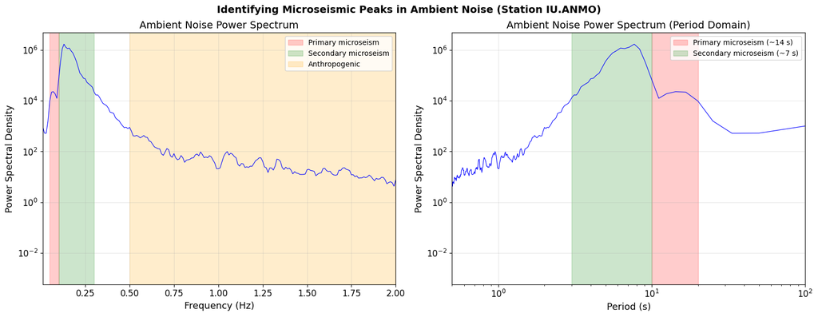

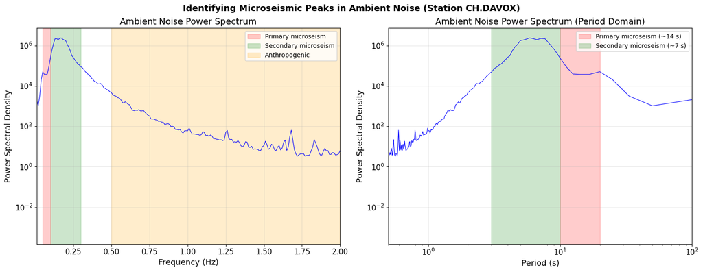

### Key Observation

The spectrum shows clear peaks at the **primary** (~0.07 Hz / ~14 s) and **secondary** (~0.14 Hz / ~7 s) microseismic periods. These are the dominant frequencies in ambient noise seismology and are generated by ocean-atmosphere interactions thousands of kilometers away.

> *"In the band of 0.3-0.05 Hz, the ambient noise is often referred to as 'microseisms'. In the microseism spectral band, the noise is dominated by surface waves, which are predominantly Rayleigh waves."* -- Campillo & Roux (2015)

# Module 2: Seismic Data Handling with ObsPy

## Refresh

[Seismo-live](https://seismo-live.github.io/) is an interactive online learning platform for seismology. It utilizes Jupyter Notebooks to introduce some seismic principle hands-on with some coding, I highly recommand to have a try at them. Obspy, nowadays, is the base of close to all packages related to seismology. For ambient noise, it is directly integrate to [Noisepy](https://github.com/noisepy/NoisePy) (Jiang, C. and Denolle, 2020) and [MSNoise](https://www.msnoise.org/) (Lecocq et al., 2014)

## 2.1 Core Data Structures

[ObsPy](https://docs.obspy.org/) (Beyreuther et al., 2010; Megies et al., 2011) is the standard Python framework for seismological data processing. Its core objects are:

- **`Trace`**: A single continuous time series with metadata (`stats` attribute containing network, station, channel, sampling_rate, starttime, etc.)
- **`Stream`**: An ordered collection of `Trace` objects (like a list of seismograms)
- **`UTCDateTime`**: Precise time representation for seismology
- **`Inventory`**: Station metadata (coordinates, instrument response, etc.)

### ObsPy Architecture for Ambient Noise

```
ObsPy
 ├── obspy.core          # Trace, Stream, UTCDateTime
 ├── obspy.clients.fdsn  # Data download from FDSN web services
 ├── obspy.signal        # Signal processing (filter, taper, etc.)
 ├── obspy.io            # I/O for various formats (SAC, miniSEED, etc.)
 └── obspy.imaging       # Plotting utilities
```

### FDSN Web Services

ObsPy can access seismic data from global data centers through the International Federation of Digital Seismograph Networks (FDSN) web services:

| Data Center | Code | Region |
| --- | --- | --- |
| IRIS DMC | `IRIS` | Global |
| ORFEUS/EIDA | `ODC` | Europe |
| GFZ | `GFZ` | Germany |
| ETH | `ETH` | Switzerland |
| RESIF | `RESIF` | France |
| INGV | `INGV` | Italy |

```
UTCDateTime object: 2020-06-15T12:30:00.000000Z
Julian day: 167
Timestamp (POSIX): 1592224200.0
Add 1 hour: 2020-06-15T13:30:00.000000Z

Trace: XX.TEST..BHZ | 2020-01-01T00:00:00.000000Z - 2020-01-01T00:00:09.990000Z | 100.0 Hz, 1000 samples
Stats:          network: XX
         station: TEST
        location:
         channel: BHZ
       starttime: 2020-01-01T00:00:00.000000Z
         endtime: 2020-01-01T00:00:09.990000Z
   sampling_rate: 100.0
           delta: 0.01
            npts: 1000
           calib: 1.0

Stream: 1 Trace(s) in Stream:
XX.TEST..BHZ | 2020-01-01T00:00:00.000000Z - 2020-01-01T00:00:09.990000Z | 100.0 Hz, 1000 samples

After preprocessing: trace is ready for cross-correlation
```

```
Station 1: ANMO
Station 2: CCM

Station ANMO: (34.95, -106.46)
Station CCM:  (38.06, -91.24)
Inter-station distance: 1404.1 km
Expected Rayleigh wave travel time (~3.5 km/s): 401 s
Azimuth: 71.3 deg
```

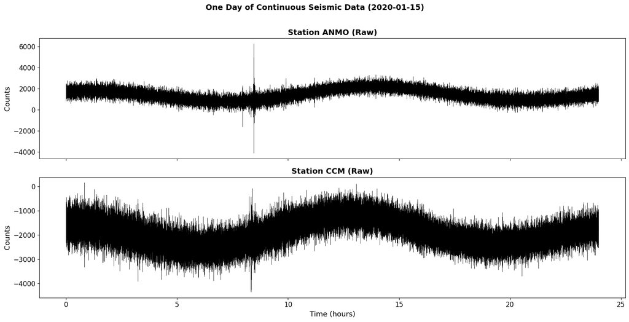

```
Note: The raw data contains ambient noise, possible earthquakes,
instrument glitches, and other transients that must be removed.
```

# Module 3: The Cross-Correlation Theorem

## 3.1 Mathematical Definition

The **cross-correlation** is a fundamental operation that measures the similarity between two signals as a function of a time lag $\tau$. For two continuous signals $u_1(t)$ and $u_2(t)$ of duration $T$, the cross-correlation is defined as (Campillo & Roux, 2015):

$$C(\vec{r}_1, \vec{r}_2; t) = C_{1,2}(t) = \frac{1}{T} \int_0^T u_1(\tau) \, u_2(t + \tau) \, d\tau \qquad [1]$$

Or equivalently, in the **frequency domain**:

$$C(\vec{r}_1, \vec{r}_2; \omega) = C_{1,2}(\omega) = u_1(\omega) \, u_2^*(\omega) \qquad [2]$$

where $u_2^*(\omega)$ is the complex conjugate of the Fourier transform of $u_2(t)$.

> This is the key equation used in NoisePy (Jiang & Denolle, 2020): $$\hat{C}_{AB}(f) = \hat{U}_A^*(f) \hat{U}_B(f) \qquad \text{[Eq. 1, Jiang & Denolle, 2020]}$$

### Physical Interpretation

The cross-correlation function measures the **resemblance** of two signals:

- When signals are **similar**, the cross-correlation peaks at the **time delay** that separates them
- The ambient noise signals recorded at distant stations are considered **uncorrelated** since they result from variable interferences between numerous waves of different types emitted by different sources
- Noise-correlation methods aim at extracting the **slight coherent part** of the signals that contains deterministic information on wave propagation between the two stations (Campillo & Roux, 2015)

### Cross-Correlation vs. Convolution

The cross-correlation is closely related to convolution:

- **Convolution**: $f * g = \int f(\tau) g(t - \tau) d\tau$ (one signal is time-reversed)
- **Cross-correlation**: $f \star g = \int f(\tau) g(t + \tau) d\tau$ (no time reversal)

In the frequency domain:

- Convolution $\Leftrightarrow$ Multiplication: $\mathcal{F}\{f * g\} = F(\omega) \cdot G(\omega)$
- Cross-correlation $\Leftrightarrow$ Conjugate multiplication: $\mathcal{F}\{f \star g\} = F^*(\omega) \cdot G(\omega)$

This is the **Cross-Correlation Theorem** (also called the **Wiener-Khinchin theorem** for auto-correlation).

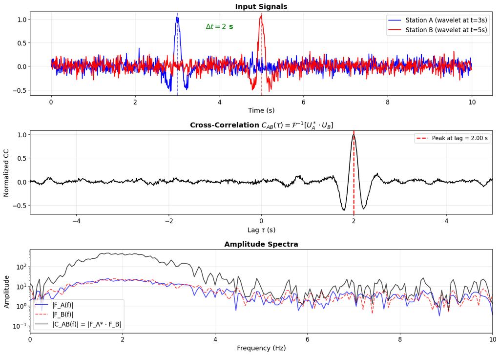

```
Peak lag: 2.0000 s
B is delayed by 2.0 s relative to A
CC peak at 2.0 s confirms this: positive lag means
B's signal arrives later than A's signal.

The Cross-Correlation Theorem:
  C_AB(f) = U_A*(f) · U_B(f)
The time-domain CC equals the inverse FFT of the conjugate product.
This is how NoisePy and all ANT codes compute CCs efficiently.
```

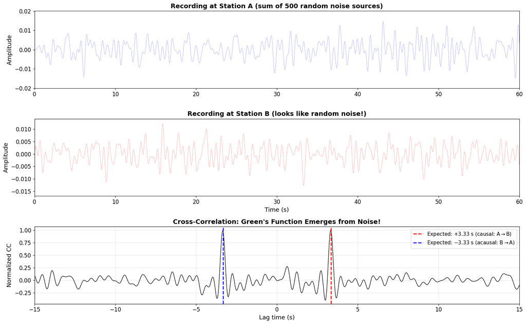

```
Expected inter-station travel time: 3.33 s
Station separation: 10.0 km
Rayleigh wave velocity: 3.0 km/s

*** The cross-correlation reveals clear peaks at +/- 3.33 s ***
This corresponds to the causal and acausal Green's function!

Physics: Each noise source creates a coherent differential delay
between the two stations. Summing over many isotropic sources,
only the stationary-phase contributions (sources along the
inter-station axis) survive — producing the surface wave arrival.
```

### Key Result: Signal Emerges from Noise!

Even though both recordings look like pure random noise, their cross-correlation reveals clear peaks at $\pm t = d/c$, where $d$ is the inter-station distance and $c$ is the wave velocity. This is the **empirical Green's function**.

The two peaks correspond to:

- **Positive lag** ($+\tau$): The **causal** Green's function (waves traveling from A to B)
- **Negative lag** ($-\tau$): The **acausal** Green's function (waves traveling from B to A)

> *"The correlation function of the fields recorded at two points is used as a virtual seismogram for which the source is acting at one point and the receiver at the second."* -- Campillo & Roux (2015)

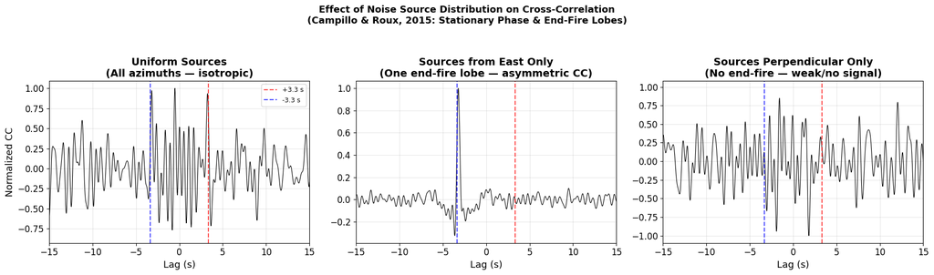

```
KEY INSIGHT (Campillo & Roux, 2015):
Only sources in the 'end-fire lobes' (aligned with the station pair)
contribute coherently to the cross-correlation via stationary phase.
• Uniform sources → symmetric CC with both causal and acausal peaks
• One-sided sources → asymmetric CC (one peak dominates)
• Perpendicular sources → no coherent signal at expected travel time

This is why STACKING over long periods improves the CC: seasonal
changes in noise source direction provide better azimuthal coverage.
```

# Module 4: Green's Function Retrieval from Ambient Noise

## 4.1 The Theoretical Foundation

The link between ambient noise cross-correlations and the Green's function has been established through several complementary theoretical frameworks.

### 4.1.1 The Time-Reversal Approach (Heuristic)

A simple, heuristic approach is based on the **analogy between correlation and a time-reversal experiment** (Derode et al., 2003; Paul et al., 2005):

1. In a time-reversal experiment, signals from an active source are recorded, numerically reversed ($t \rightarrow -t$), and re-emitted in the medium
2. Due to the **time symmetry** of wave equations, the waves propagate back and focus on the original source position
3. The cross-correlation of noise recordings achieves mathematically the same effect as this time-reversal process

In the frequency domain, the cross-correlation $C_{1,2}(\omega) = u_1(\omega) u_2^*(\omega)$ is equivalent to having source at position 1, the signal is time-reversed and re-emitted from position 2 (Campillo & Roux, 2015).

### 4.1.2 Mathematical Derivation: Plane-Wave Approximation

Following Campillo & Roux (2015), for the 2D case with scalar waves:

The plane waves at angular frequency $\omega$ generated from sources at large distances, propagating in direction $\psi$, have the form:

$$u(\vec{r}_1; \omega) = F(\omega) \exp(i k \vec{r}_1 \cdot \hat{n}) \qquad [4]$$

where $k = \omega/c$ is the wavenumber, $\hat{n} = (\cos\psi, \sin\psi)$ is the propagation direction, and $F(\omega)$ is the source amplitude.

Assuming an **omnidirectional distribution** of incident plane waves, the field correlation between two points separated by distance $r = |\vec{r}_1 - \vec{r}_2|$ reduces to:

$$\langle u(\vec{r}_1; \omega) u^*(\vec{r}_2; \omega) \rangle = |F(\omega)|^2 J_0(k|\vec{r}_1 - \vec{r}_2|) \qquad [5]$$

where $J_0$ is the **Bessel function of the first kind and order 0**. This is the essence of the spatial correlation methods proposed by **Aki (1957)**.

The 2D scalar Green's function can be identified as:

$$G(\vec{r}_1, \vec{r}_2; \omega) = \frac{1}{4i} H_0^{(1)}(k|\vec{r}_1 - \vec{r}_2|) = \frac{1}{4i}(J_0(k|\vec{r}_1 - \vec{r}_2|) + iY_0(k|\vec{r}_1 - \vec{r}_2|)) \qquad [6]$$

Leading to the fundamental result:

$$\boxed{\langle u(\vec{r}_1; \omega) u^*(\vec{r}_2; \omega) \rangle = -4|F(\omega)|^2 \text{Im}[G(\vec{r}_1, \vec{r}_2; \omega)]} \qquad [7]$$

**This equation states that the average noise cross-correlation is proportional to the imaginary part of the Green's function.**

### 4.1.3 The Time-Domain Connection

Taking the time derivative of the normalized correlation function (eq. [10] in Campillo & Roux, 2015):

$$\frac{d}{dt} C_{1,2}(t) = \frac{1}{4\pi r/c} [\delta(t + r/c) - \delta(t - r/c)] \qquad [11]$$

The two terms correspond to the **backward and forward Green's function** between the receivers, demonstrating the connection between the correlation function and the Green's function.

### 4.1.4 Generalization (Wapenaar, 2004)

For an **arbitrary heterogeneous medium** with attenuation parameter $\kappa \neq 0$, the Green's function between points A and B is defined as the solution of:

$$\Delta G(\vec{x}; t) - \frac{1}{c^2} \frac{\partial G(\vec{x}; t)}{\partial t^2} = \delta(\vec{x}) \delta(t) \qquad [3]$$

Wapenaar (2004) and Snieder (2004) showed rigorously that the cross-correlation result generalizes to elastic media with heterogeneity.

# Module 5: Ambient Noise Preprocessing

## 5.1 The Preprocessing Workflow

Following **Bensen et al. (2007)**, the ambient noise data processing divides into **four principal phases**:

```
Phase 1: Single-Station Data Preparation
    Raw data → Remove instrument response → Remove mean & trend →
    Bandpass filter → Cut to 1-day segments →
    Apply temporal normalization → Apply spectral whitening

Phase 2: Cross-Correlation & Stacking
    Compute daily cross-correlations → Stack to desired number of days

Phase 3: Dispersion Measurement
    Measure group and/or phase velocity

Phase 4: Quality Control
    Error analysis → Selection of acceptable measurements
```

The preprocessing steps impose **non-linear modifications** to the waveforms, so the **order of operations is significant** (Bensen et al., 2007).

## 5.2 Temporal Normalization

The most important step in single-station data preparation. Its purpose is to **reduce the effect of earthquakes, instrumental irregularities, and non-stationary noise sources** on the cross-correlations (Bensen et al., 2007).

### Five methods compared by Bensen et al. (2007):

| Method | Description | Reference |
| --- | --- | --- |
| **One-bit normalization** | Replace amplitudes with $\pm 1$ based on sign | Campillo & Paul (2003) |
| **Clipped waveform** | Clip to RMS amplitude of the day | Sabra et al. (2005) |
| **Automated event detection** | Zero out windows above threshold | - |
| **Running-absolute-mean (RAM)** | Weight by inverse of running mean | **Preferred by Bensen et al.** |
| **Water-level normalization** | Iteratively down-weight above threshold | - |

### Running-Absolute-Mean Normalization

For a discrete time series $d_j$, the normalization weight at time point $n$ is (Bensen et al., 2007, Eq. 1):

$$w_n = \frac{1}{2N + 1} \sum_{j=n-N}^{n+N} |d_j|$$

The normalized datum becomes: $\tilde{d}_n = d_n / w_n$

The width of the normalization window $(2N + 1)$ determines how much amplitude information is retained.

### Earthquake-Band Temporal Normalization

If $d_j$ is the raw seismogram and $\hat{d}_j$ is the seismogram bandpass filtered in the earthquake band, the weights become (Bensen et al., 2007, Eq. 2):

$$\hat{w}_n = \frac{1}{2N + 1} \sum_{j=n-N}^{n+N} |\hat{d}_j|$$

These weights are then applied to the **raw data**: $\tilde{d}_n = d_n / \hat{w}_n$

## 5.3 Spectral Whitening

Ambient noise is **not spectrally flat** - it is peaked near the primary (~15 s) and secondary (~7.5 s) microseisms. Spectral whitening serves to (Bensen et al., 2007):

1. **Broaden the band** of the ambient noise signal in cross-correlations
2. **Combat degradation** caused by persistent monochromatic sources (e.g., the 26 s Gulf of Guinea signal)
3. Enable **broad-band dispersion measurement**

The whitening is achieved by **inversely weighting** the complex spectrum by a smoothed version of the amplitude spectrum.

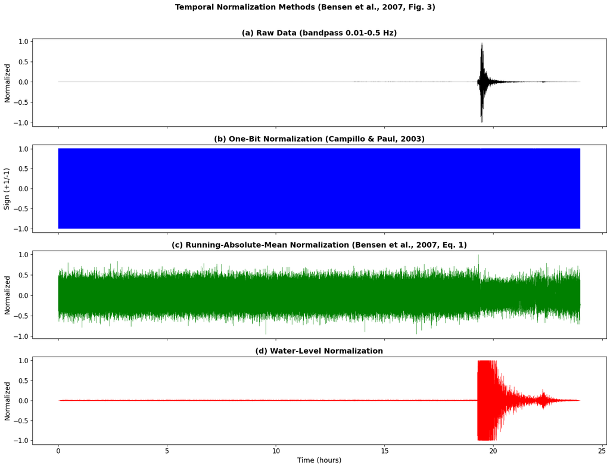

```
Bensen et al. (2007) recommend Running-Absolute-Mean normalization
for its flexibility and adaptability to the data.
One-bit normalization is the most aggressive but effective approach.
```

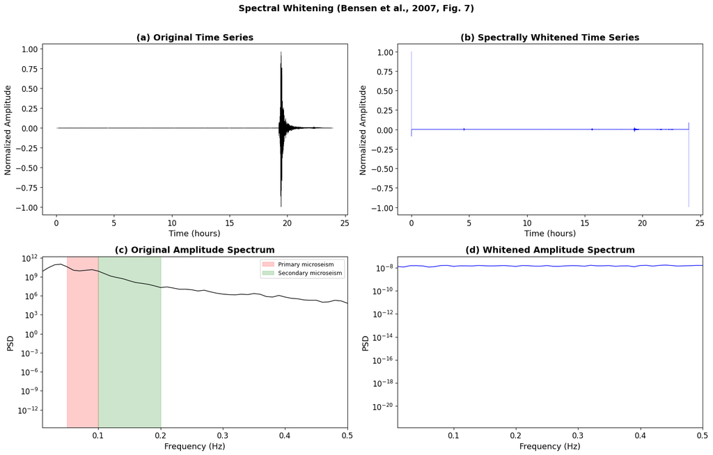

```
Spectral whitening flattens the amplitude spectrum while preserving phase.
This broadens the frequency content of cross-correlations and removes
the dominance of the microseismic peaks (Bensen et al., 2007).
```

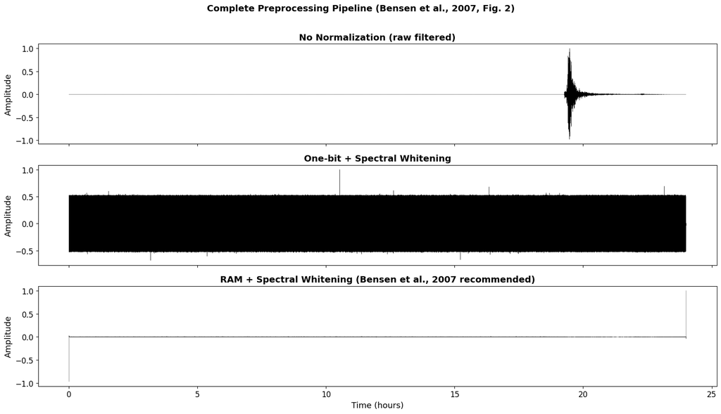

# Module 6: Cross-Correlation Computation

## 6.1 Cross-Correlation Methods

NoisePy (Jiang & Denolle, 2020) implements several cross-correlation methods, controlled by the `cc_method` parameter:

| Method | `cc_method` | `freq_norm` | Description |
| --- | --- | --- | --- |
| **Pure cross-correlation** | `'xcorr'` | `'no'` | $\hat{C}_{AB}(f) = \hat{U}_A^*(f) \hat{U}_B(f)$ |
| **Coherency** | `'xcorr'` | `'rma'` | $\hat{C}_{AB}(f) = \frac{\hat{U}_A^*(f) \hat{U}_B(f)}{\{\lvert\hat{U}_A(f)\rvert\}\{\lvert\hat{U}_B(f)\rvert\}}$ |
| **Deconvolution** | `'deconv'` | `'no'` | $\hat{C}_{AB}(f) = \frac{\hat{U}_A^*(f) \hat{U}_B(f)}{\{\lvert\hat{U}_A(f)\rvert^2\}}$ |
| **Phase cross-correlation** | `'xcorr'` | `'phase_only'` | Amplitude set to 1 |

Where $\{\cdot\}$ represents smoothing using a running mean average (Jiang & Denolle, 2020, Table 1).

> *"Performing spectral whitening using rma with the cross correlation is strictly equivalent to calculating the coherency."* -- Jiang & Denolle (2020), citing Prieto et al. (2009)

## 6.2 Practical Considerations

- Cross-correlations are computed on **daily segments** (or sub-daily windows)
- All station pairs yield $n(n-1)/2$ cross-correlations for $n$ stations
- NoisePy splits continuous data into **time chunks (TC)** to optimize memory (Jiang & Denolle, 2020, Eq. 4)

```
Computing cross-correlation (this may take a moment)...
Number of windows used: 181
Lag range: -500 to 500 s
Expected Rayleigh wave arrival: ~401 s at 3.5 km/s
```

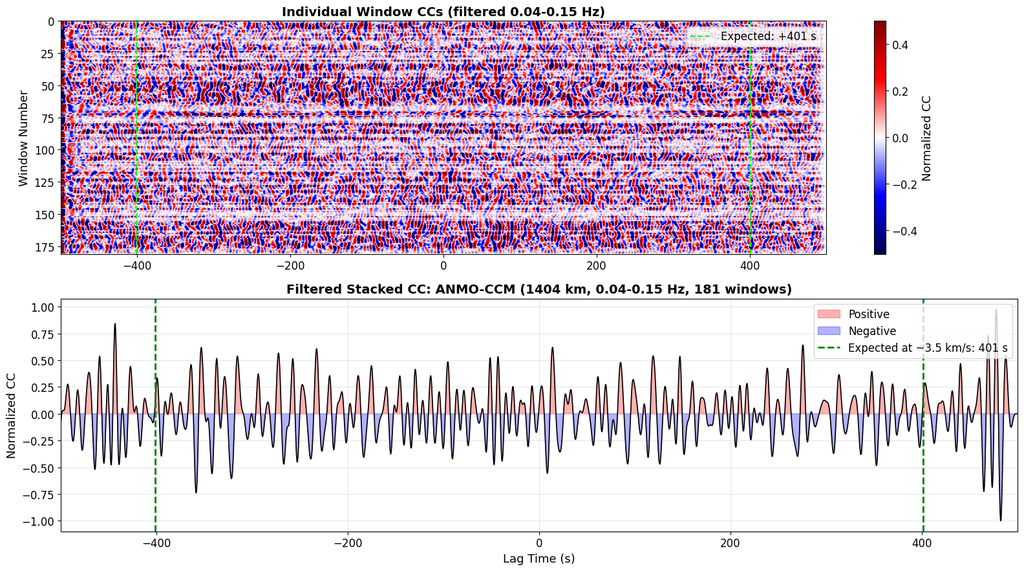

[output not shown]

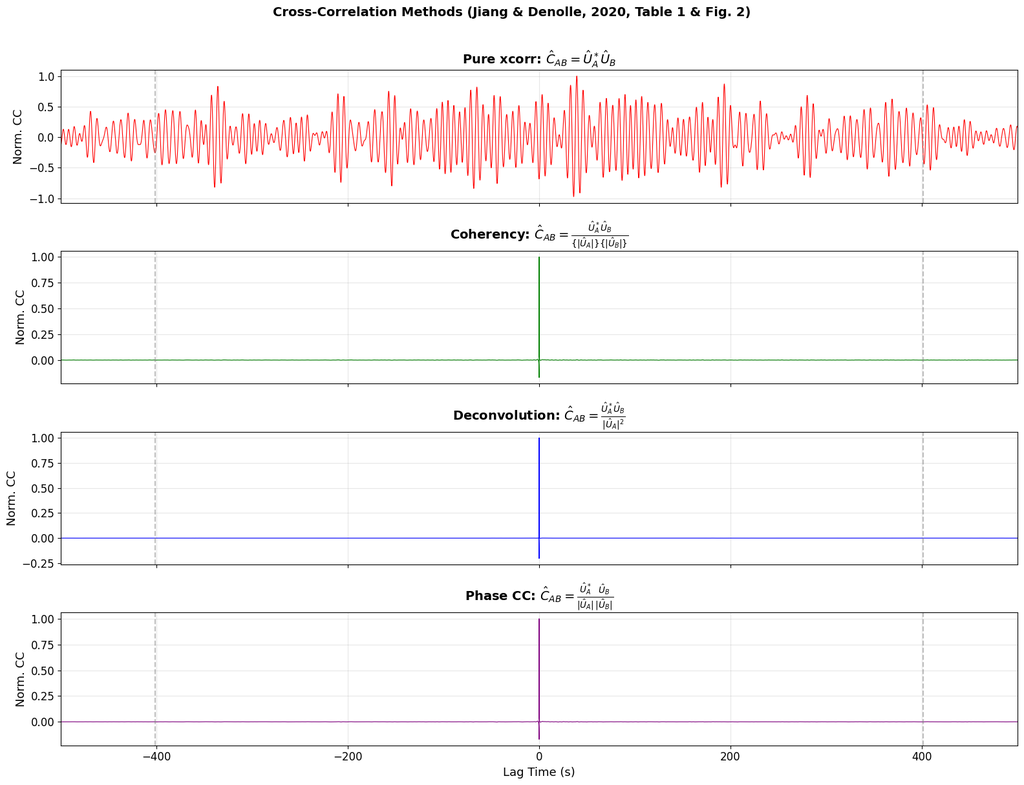

```
Simulating 8 stations, 28 pairs, 300 sources, 50 windows...
```

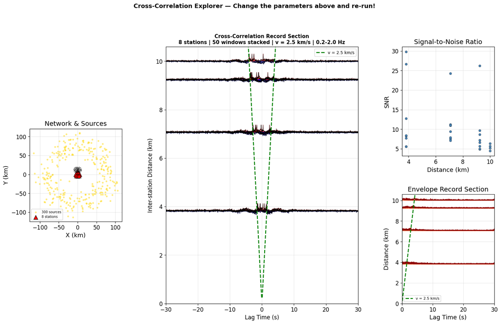

```
============================================================
  EXPERIMENT SUMMARY
============================================================
  Network:       8 stations, circular layout, radius 5.0 km
  Pairs:         28 cross-correlations
  Distance range:3.8 — 10.0 km
  Wave velocity: 2.5 km/s
  Frequency:     0.2—2.0 Hz
  Sources:       300 (uniform), ring at 80.0 km
  Stacking:      50 windows × 120.0s = 1.7 hours
  Processing:    one-bit=True, whitening=True
  Attenuation:   Q = 200
============================================================

  Try changing these parameters and re-running:
    • rayleigh_vel: 1.0 → 4.0 km/s (shifts the moveout slope)
    • n_sources: 30 → 3000 (fewer = noisier, asymmetric CCs)
    • source_distribution: 'directional' (breaks causal/acausal symmetry)
    • n_windows: 5 → 500 (more stacking = cleaner signal)
    • freq_band: (0.1, 0.5) vs (1.0, 5.0) (controls wavelength)
    • attenuation_Q: 50 → 1000 (low Q kills distant pairs)
    • apply_one_bit: False (compare with/without normalization)
    • geometry: 'circular' or 'random' (changes distance sampling)
```

# Module 7: Stacking Methods

## 7.1 Why Stacking?

Individual daily cross-correlations are noisy. **Stacking** (temporal averaging) improves the signal-to-noise ratio (SNR) by reinforcing coherent signals while averaging out incoherent noise. The SNR of the cross-correlation improves with longer recording time because more noise sources participate coherently (Campillo & Roux, 2015).

> *"The averaging of the correlation process over time magnifies the coherent versus incoherent contributions of the noise sources."* -- Campillo & Roux (2015)

## 7.2 Stacking Methods in NoisePy

NoisePy (Jiang & Denolle, 2020) implements several stacking options in the S2 script:

| Method | Description | Reference |
| --- | --- | --- |
| **Linear stacking** | Simple average | Standard |
| **Phase-weighted stacking (PWS)** | Weight by instantaneous phase coherence | Schimmel & Paulssen (1997) |
| **Robust stacking** | Iterative reweighting | Pavlis & Vernon (2010) |
| **Autocovariance filter** | Filter based on autocovariance | Nakata et al. (2016) |
| **Selective stacking** | Select based on CC coefficient quality | Yang et al. (2020) |

### Phase-Weighted Stack (PWS)

The PWS enhances coherent arrivals by weighting each sample by the **coherence of the instantaneous phase** across all windows (Schimmel & Paulssen, 1997):

$$\text{PWS}(t) = \frac{1}{N} \sum_{i=1}^{N} s_i(t) \left| \frac{1}{N} \sum_{j=1}^{N} e^{i\phi_j(t)} \right|^\nu$$

where $\phi_j(t)$ is the instantaneous phase of the $j$-th trace and $\nu$ is the power index (typically $\nu = 2$).

[output not shown]

[figure not shown]

[figure not shown]

# Extra Module 8: Optimal Processing of Noise Correlations for pure scientific curriosity and maybe for R&D

## 8.1 The Problem with Standard Processing

Standard preprocessing (one-bit normalization, spectral whitening) is **nonlinear** — it breaks the linear wave physics that underlies the Green's function retrieval theorem. This has important consequences (Fichtner et al., 2020).

### The Transfer Coefficient Framework

**Fichtner et al. (2020)** introduced a rigorous framework to quantify processing effects. For each time window $n$ and station pair $(i,k)$, they define a **transfer coefficient**:

$$\tilde{I}^{(n)}(\xi_i, \xi_k) = T_{ik}^{(n)} \cdot I^{(n)}(\xi_i, \xi_k) \qquad [\text{Fichtner et al., 2020, Eq. 7}]$$

where $I^{(n)}$ is the raw interferogram and $\tilde{I}^{(n)}$ is the processed one.

### The Key Factorization Theorem

The transfer coefficient **always factorizes** as:

$$T_{ik}^{(n)} = f^{(n)} \cdot g_{ik} + e_{ik}^{(n)} \qquad [\text{Fichtner et al., 2020, Eq. 8}]$$

where:

- $f^{(n)}$ = **time-window-specific scalar** (captures amplitude variation over time)
- $g_{ik}$ = **path-specific complex weight** (depends only on station pair)
- $e_{ik}^{(n)}$ = **factorization residual** — responsible for all **unphysical** effects

### Why This Matters

The residual $e_{ik}^{(n)}$ introduces an **unphysical wavefield**: different station pairs effectively see different noise source distributions. This means:

| Processing | Residual $e$ | Physical Impact | Reference |
| --- | --- | --- | --- |
| One-bit normalization | **Large** | ~10 dB amplitude error, ~2.9% traveltime bias | Fichtner et al. (2020) |
| Spectral whitening | Medium | Primarily amplitude effect | Fichtner et al. (2020) |
| Causal/acausal averaging | **Large** | Mixes two different wave packets as different sources | Fichtner et al. (2017) |
| Optimal processing (OPUS) | **Zero** | Preserves all desired properties | Fichtner et al. (2020) |

### Optimal Processing (OPUS)

The **optimal processed interferogram** eliminates the unphysical component:

$$\tilde{I}_{\text{opt}}^{(n)}(\xi_i, \xi_k) = f^{(n)} \cdot g_{ik} \cdot I^{(n)}(\xi_i, \xi_k) \qquad [\text{Fichtner et al., 2020, Eq. 12}]$$

> *"Do NOT equate interferometry with Green's function retrieval. Instead, extract information directly from processed correlations by developing an effective forward theory that accounts for the processing."* — Fichtner et al. (2017)

### Generalised Interferometry

**Fichtner et al. (2017)** developed a unified framework that works for any processing:

1. Compute the **effective source power spectral density** $\tilde{S}(x,x')$ that accounts for the processing
2. Use this in a **forward model** to predict what the processed correlation should look like
3. Invert for Earth structure using the effective forward model — no Green's function approximation needed

This framework unifies earthquake-based methods, ambient noise correlations, and any other source of inter-station correlations.

# Module 9: Surface Wave Dispersion Analysis

Surface waves (Rayleigh and Love waves) are **dispersive**: their velocity depends on frequency (or period). This dispersion arises because different frequencies sample **different depths** of the Earth:

- **Short periods** (high frequency): Sensitive to shallow structure
- **Long periods** (low frequency): Sensitive to deeper structure

The dispersion of surface waves recovered from ambient noise cross-correlations provides information about the **velocity structure** of the crust and uppermost mantle (Shapiro & Campillo, 2004; Bensen et al., 2007).

### Group Velocity vs. Phase Velocity

- **Group velocity** $U = d\omega/dk$: Velocity of the wave envelope
- **Phase velocity** $c = \omega/k$: Velocity of individual wave crests

Both can be measured from noise cross-correlations:

- Group velocity: From **frequency-time analysis** (FTAN) using narrow-band filtering
- Phase velocity: From the **phase** of the cross-correlation spectrum

### NoisePy Dispersion Analysis

NoisePy implements group velocity measurement using (Jiang & Denolle, 2020):

1. **Continuous Wavelet Transform (CWT)** using Morlet wavelets (Fichtner et al., 2008)
2. **Automated Frequency-Time Analysis (AFTAN)** (Levshin & Ritzwoller, 2001; Bensen et al., 2007)

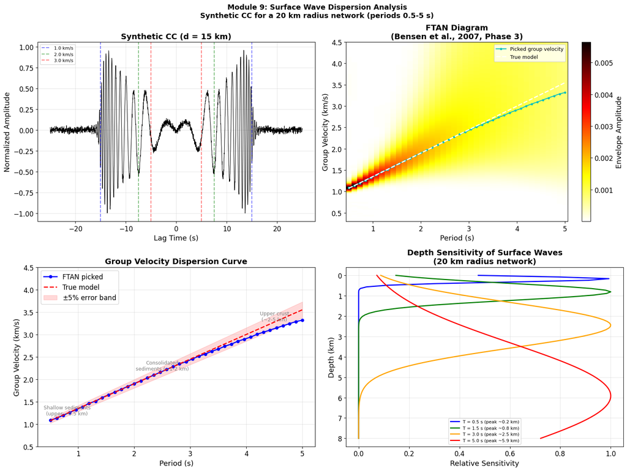

[output not shown]

## 9.2 Our Dispersion Picking Workflow

### Step 1: Extract Dispersion Curves (`dispersion_curves.py`)

For each stacked station-pair `.h5` file, this script:

1. **Loads the stacked CC** from ASDF (e.g., `Allstack_pws`) for each component (ZZ, RR, TT, or all 9 after rotation)
2. **Separates positive, negative, and symmetric lags**:

   ```
   cc_neg = tdata[:indx+1][::-1]   # Flip negative lag
   cc_pos = tdata[indx:]            # Positive lag
   cc_sym = 0.5 * (cc_pos + cc_neg) # Symmetric average
   ```

3. **Trims to velocity window** [`vmin`, `vmax`] based on inter-station distance
4. **Computes CWT** using Morlet wavelets (`pycwt`), producing a period × velocity dispersion image
5. **Normalizes** each period row by its maximum
6. **Picks group velocity** using one of two methods:
   - **`argmax`**: Tracks the global maximum at each period with continuity constraints (`maxgap` parameter) and minimum wavelength criterion (`dist / (T × vg) > minlambda`)
   - **`topology`**: Uses topological persistence (`findpeaks` library) to identify all significant peaks at each period, with a `limit` threshold on persistence score
7. **Computes SNR** via narrowband Gaussian filtering at each picked period:

   ```
   GaussFilt = exp(-alpha * ((f - f0) / f0)^2)
   SNR = max(signal_window) / RMS(noise_window)
   ```

8. **Writes picks** to CSV: `inst_period, group_velocity, score, snr_nbG, snr_bb, ratio_d_lambda, azimuth, backazimuth, distance`

#### V2: Multi-Component Products

Our improved version (`dispersion_curves_V2.py`) also computes **geometric-mean products** of multiple FTAN images for more robust picks:

- **ZZ × ZR × RZ × RR** (pos & neg lags): `(amp_ZZ_pos * amp_ZZ_neg * amp_ZR_pos * ... * amp_RR_neg)^(1/8)`
- **ZZ × ZR** (symmetric lag): `(amp_ZZ_sym * amp_ZR_sym)^(1/2)`
- **RR × RZ** (symmetric lag): `(amp_RR_sym * amp_RZ_sym)^(1/2)`

These products enhance coherent dispersion signal while suppressing component-specific noise.

### Step 2: Merge All Picks (`step1_merge_picks.py`)

Collects all per-pair CSV files into one large table with quality control:

```
# Quality thresholds
snr_nbG_thresh = 10.0   # Minimum narrowband SNR
d_lambda_thresh = 1.0   # Minimum distance/wavelength ratio (d > 1 wavelength)

# Filter
df = df.loc[(df.snr_nbG > snr_nbG_thresh) & (df.ratio_d_lambda > d_lambda_thresh)]
```

### Step 3: Pick Density Histograms (`step2_pick_histograms.py`)

Visualizes the merged picks as 2D density histograms (period vs. group velocity), one panel per component. Overlays the mean ± 2σ dispersion curve in white. This allows quick assessment of:

- Which periods have reliable data
- Whether picks are consistent across components
- If there are spurious branches or mode jumps

### HPC Parallelization

Dispersion picking is embarrassingly parallel — each station pair is independent. We use SLURM array jobs:

```
#SBATCH --array=0-40%     # 41 array tasks
for k in $(seq 0 99); do  # Each task processes 100 pairs
    ROW=$(( ${SLURM_ARRAY_TASK_ID} * 100 + $k ))
    sfile=$(sed -n "${ROW}p" $fname)
    python dispersion_curves_V2.py $sfile
done
```

This processes thousands of station pairs efficiently on a cluster.

### Key Parameters to Tune

| Parameter | Typical Value | Effect |
| --- | --- | --- |
| `vmin`, `vmax` | 0.5–4.5 km/s | Velocity search window |
| `Tmin`, `dT` | 0.05 s, 0.01 s | Minimum period and sampling |
| `maxgap` | 3 | Max gap in velocity picks (× dvel) |
| `alpha` (SNR) | 5–10 | Gaussian filter width for narrowband SNR |
| `limit` (topology) | 0.1–0.3 | Persistence threshold for peak detection |
| `snr_nbG_thresh` | 5–10 | Minimum SNR to retain a pick |
| `d_lambda_thresh` | 1.0–1.5 | Minimum distance/wavelength ratio |

# Module 10: Ambient Noise Tomography — From Dispersion Curves to 2D Velocity Maps

## 10.1 The 2D Tomographic Problem

Once dispersion curves have been measured for all station pairs via FTAN (Module 9), the next step is to **invert** the interstation group or phase velocities into **2D velocity maps** at each period. This is the classic **surface wave tomography** problem (Bensen et al., 2008; Rawlinson et al., 2010).

### From Dispersion Curves to Tomographic Input

Each dispersion curve provides the group velocity $v_g(\tau)$ as a function of period $\tau$ for one station pair. At a given period, the **interstation travel time** is:

$$t_{ij}(\tau) = \frac{\Delta_{ij}}{v_{g,ij}(\tau)}$$

where $\Delta_{ij}$ is the interstation distance and $v_{g,ij}(\tau)$ is the measured group velocity. These travel times (or equivalently the measured slownesses $s_{ij} = 1/v_{g,ij}$) constitute the **data vector** $\mathbf{d}$ for the tomographic inversion.

### The Forward Problem

Under the straight-ray (great-circle) approximation, the travel time between stations $i$ and $j$ is (Rawlinson et al., 2010):

$$t_{ij}(\tau) = \int_{\text{path}_{ij}} \frac{1}{c(\vec{r}, \tau)} \, dl = \int_{\text{path}_{ij}} s(\vec{r}, \tau) \, dl$$

where $s = 1/c$ is the **slowness field**. Discretizing the surface into cells, the travel time becomes:

$$t_{ij} = \sum_{k=1}^{M} G_{ij,k} \cdot s_k$$

where $G_{ij,k}$ is the **path length of ray $ij$ through cell $k$** (the Jacobian/sensitivity matrix), and $s_k$ is the slowness in cell $k$.

### Linear vs Nonlinear Inversion

**Linear inversion** assumes straight-line ray paths. The damped least-squares solution is (Rawlinson et al., 2010; Cabrera-Pérez et al., 2021, Eq. 2):

$$\delta\mathbf{m} = \left(\mathbf{G}^T \mathbf{G} + \epsilon \mathbf{L}_\theta\right)^{-1} \mathbf{G}^T \mathbf{d}_{\text{res}}$$

where the **combined damping matrix** blends zeroth-order (identity) and second-order (Laplacian) Tikhonov regularization:

$$\mathbf{L}_\theta = \epsilon \left[L_0 (1-\theta) + L_2 \theta\right]$$

- $\theta = 0$: pure damping (penalizes large perturbations)
- $\theta = 1$: pure smoothing (penalizes rough models)
- $\theta = 0.5$: optimal blend found by Cabrera-Pérez et al. (2021)
- $\epsilon$ is selected via the **L-curve** method (Hansen, 1992)

**Nonlinear inversion** uses the Levenberg-Marquardt approach and **recomputes ray paths** at each iteration using the Shortest Path algorithm (Moser, 1991; Klimeš & Kvasnička, 1994), correctly handling strong lateral contrasts.

### The Multiscale Approach: MANgOSTA

**Cabrera-Pérez et al. (2021)** introduced MANgOSTA (Multiscale Ambient NOiSe TomogrAphy), which progressively increases model resolution:

1. **Scale 0**: Homogeneous model (1 parameter)
2. **Scale 1**: $3 \times 3$ grid → nonlinear inversion with Shortest Path ray tracing
3. **Scale $s$**: $(2^{s-1}+1)^2$ nodes → use previous scale as starting model

The upgrade operator $U^{(s)}: M^{(s)} \to M^{(s+1)}$ maps the best-fitting model to the finer scale:

$$F(m^{(s)}) \equiv F(U^{(s)}(m^{(s)}))$$

This avoids local minima and works well even with sparse networks and strong velocity contrasts, making it ideal for volcanic and geothermal exploration.

### Bayesian Tomography with BayesBay

An alternative is the **transdimensional Bayesian approach** using BayesBay (Magrini, He & Sambridge, 2025). It implements **Reversible-Jump MCMC** (RJ-MCMC) which:

1. Parameterizes the velocity field using **2D Voronoi tessellation** — the number and positions of nuclei are free parameters
2. Samples the posterior $p(\mathbf{m}|\mathbf{d}) \propto p(\mathbf{d}|\mathbf{m}) \cdot p(\mathbf{m})$
3. Infers the data noise $\sigma$ alongside the model
4. Produces **uncertainty maps** as a natural byproduct

The acceptance probability for a proposed model $\mathbf{m}'$ is:

$$\alpha(\mathbf{m}'|\mathbf{m}) = \frac{p(\mathbf{d}|\mathbf{m}')}{p(\mathbf{d}|\mathbf{m})} \cdot \frac{p(\mathbf{m}')}{p(\mathbf{m})} \cdot \frac{q(\mathbf{m}|\mathbf{m}')}{q(\mathbf{m}'|\mathbf{m})} \cdot |\mathbf{J}|$$

The transdimensional nature (birth/death of Voronoi cells) acts as Occam's razor — favoring the simplest model that fits the data.

### Depth Sensitivity: Why Period Maps Matter

Surface waves at different periods sample different depths:

| Period (s) | Approximate Depth Sensitivity |
| --- | --- |
| 0.5–2 | 0.1–1 km (near-surface, engineering) |
| 2–8 | 1–10 km (upper crust, geothermal) |
| 8–20 | 5–30 km (mid-crust) |
| 20–40 | 20–80 km (lower crust, Moho) |

```
Network: 20 stations, 137 station pairs with dispersion curves
Periods: [0.5 1.  1.5 2.  3.  4.  5. ] s
```

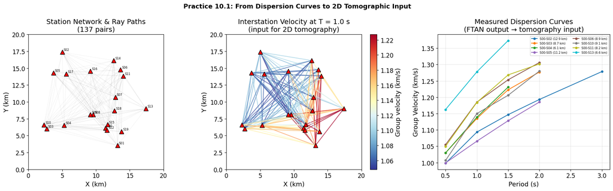

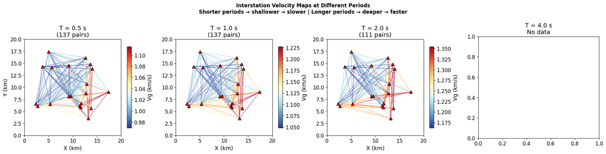

[output not shown]

```
  T=0.5s: eps_opt=9.10e+02, Vmean=1.017 km/s
  T=1.0s: eps_opt=9.10e+02, Vmean=1.115 km/s
  T=2.0s: eps_opt=9.10e+02, Vmean=1.237 km/s
  Not enough data at T=4.0s: 0 pairs
```

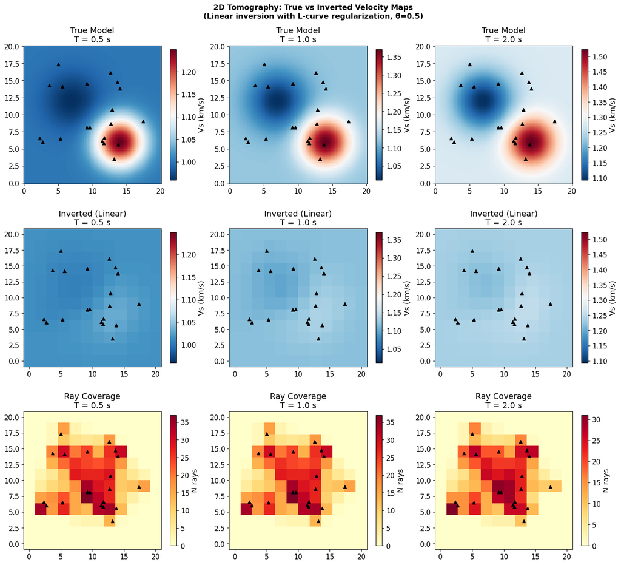

```
Key observations:
• The main anomalies are recovered, but smoothed (due to regularization)
• Resolution depends on path density — edges of the network are poorly resolved
• The L-curve automatically selects the optimal regularization strength
• This is the simplest approach — MANgOSTA and BayesBay improve on this significantly
```

## 10.2 MANgOSTA: Nonlinear Multiscale Inversion

The code **MANgOSTA** (Cabrera-Pérez et al., 2021) implements three inversion strategies:

### Architecture

MANgOSTA is structured as a modular Python package with the following key components:

| Module | Role |
| --- | --- |
| `Tomo/tomo.py` | Main tomography engine: reads dispersion data, builds Jacobian, runs inversion |
| `Tomo/inverse.py` | Inversion algorithms: Tikhonov (TIKH) and Truncated SVD (TSVD) |
| `Tomo/velmod.py` | Velocity model: handles scale-dependent parameterization and interpolation |
| `Tomo/ttime2D.py` | 2D travel time computation via Shortest Path algorithm |
| `FTAN/ftan.py` | Frequency-Time Analysis for dispersion curve extraction |
| `Correlator/` | Cross-correlation computation |
| `Stacker/` | Stacking of cross-correlations |

### Input Format

MANgOSTA reads dispersion curves from files named `disp_ZZ_STA1_STA2_*.dat` containing:

```
12345.0          ← interstation distance (m)
0.50  1.200      ← period (s), group velocity (km/s)
1.00  1.350
1.50  1.450
...
```

### Inversion Workflow

```
1. Read all dispersion curves (disp_ZZ_STA1_STA2.dat)
2. For each period:
   a. Collect travel times: t_ij = dist_ij / vg_ij(T)
   b. Compute average velocity → initial homogeneous model
   c. Choose inversion mode:

      LINEAR:  Straight rays → build Jacobian G → solve with TIKH or TSVD

      NONLINEAR: Start with linear solution → switch to log-slowness
                 → iterate: Shortest Path rays → Jacobian → Levenberg-Marquardt
                 → stop when |dm/m| < threshold

      MULTISCALE: Scale 0 (homogeneous) → Scale 1 (3×3) → Scale 2 (5×5) → ...
                  At each scale: nonlinear inversion
                  Upgrade: interpolate best model to next finer grid
   d. Write: velocity map, ray paths, residuals, nodes
```

### Key Implementation Details

**Jacobian computation** — The sensitivity matrix $G$ is computed by numerical finite differences:

```
# For each model parameter k:
mod[k] += DELTAM        # Perturb one slowness value
tk = getsynth(...)      # Recompute all travel times
G[:, k] = (tk - T0) / DELTAM  # Finite-difference derivative
```

**Shortest Path travel times** — The `TTime2D` class implements the algorithm of Klimeš & Kvasnička (1994):

- The model is discretized onto a grid with 8 nodes per cell (on cell edges)
- Travel times are propagated from source to all nodes via an expanding-circle sweep
- Ray paths are traced backward from receiver to source using the shortest-path graph

**Scale upgrade** — When moving from scale $s$ to $s+1$:

```
V = coef2mod(sc1, m)    # Convert coefficients → interpolation function
m2 = mod2coef(V, sc2)   # Sample the function at the new (finer) grid nodes
```

**Regularization selection** — MANgOSTA scans 100 values of $\epsilon$ and selects the optimum using:

1. The L-curve criterion (maximum curvature in log-log space)
2. Generalized Cross-Validation (GCV)
3. Takes the more conservative (smaller $\epsilon$) of the two

## 10.3 BayesBay: Transdimensional Bayesian Tomography

**BayesBay** (Magrini, He & Sambridge, 2025) is a general-purpose Python package for transdimensional Bayesian inversion. For 2D surface wave tomography, it uses **Voronoi tessellation** to discretize the velocity field.

### Why Bayesian?

| Deterministic (MANgOSTA) | Bayesian (BayesBay) |
| --- | --- |
| Single "best" model | Ensemble of plausible models |
| Regularization chosen subjectively | Complexity determined by data |
| No uncertainty estimate | Posterior standard deviation = uncertainty map |
| Fast (seconds to minutes) | Slower (minutes to hours, parallelizable) |
| Fixed grid resolution | Adaptive resolution (more cells where data demands) |

### BayesBay Workflow

```
1. Define the parameterization:
   - Voronoi2D: nuclei positions (lon, lat) + velocity at each nucleus
   - Prior: UniformPrior on velocity (e.g., vmin=0.5, vmax=4.0 km/s)
   - Number of Voronoi cells: free parameter (e.g., 50–1500)

2. Define the forward function:
   def forward(state):
       # Get Voronoi tessellation from current model state
       vor = state['voronoi']
       # Map Voronoi cells to regular grid using kd-tree
       nearest = kdtree.query(grid_points)[1]
       interp_vel = vor.get_param_values('vel')[nearest]
       # Forward: travel time = Jacobian × slowness
       return jacobian @ (1.0 / interp_vel)

3. Define the likelihood:
   - Target: observed slowness data with unknown noise (std_min=0, std_max=1.0)
   - Noise standard deviation is inferred alongside the model

4. Run MCMC:
   - Multiple parallel chains (e.g., 20 chains)
   - Burn-in phase: 50,000–100,000 iterations
   - Main phase: 100,000–150,000 iterations
   - Save every 300–500 iterations

5. Post-processing:
   - Mean velocity map from posterior samples
   - Standard deviation map (uncertainty)
   - Random Voronoi realizations (visual check)
   - Convergence diagnostics (log-likelihood, number of cells)
```